# An R package for Reactome Pathway Analysis

Guangchuang Yu School of Public Health, The University of Hong Kong

2018-01-29

# Introduction

This package is designed for reactome pathway-based analysis. Reactome is an open-source, open access, manually curated and peer-reviewed pathway database.

# Citation

If you use ReactomePA(Yu and He 2016) in published research, please cite:

*G Yu*, QY He*. ReactomePA: an R/Bioconductor package for reactome pathway analysis and visualization. *Molecular BioSystems* 2016, 12(2):477-479. doi: 10.1039/C5MB00663E

# Supported organisms

Currently ReactomePA supports several model organisms, including ‘celegans’, ‘fly’, ‘human’, ‘mouse’, ‘rat’, ‘yeast’ and ‘zebrafish’. The input gene ID should be Entrez gene ID. We recommend using `clusterProfiler::bitr` to convert biological IDs. For more detail, please refer to [bitr: Biological Id TranslatoR](http://www.bioconductor.org/packages/release/bioc/vignettes/clusterProfiler/inst/doc/clusterProfiler.html#bitr-biological-id-translator).

# Pathway Enrichment Analysis

Enrichment analysis is a widely used approach to identify biological themes. Here, we implement hypergeometric model to assess whether the number of selected genes associated with reactome pathway is larger than expected. The *p* values were calculated based the hypergeometric model(Boyle et al. 2004).

```r
library(ReactomePA)
data(geneList)
de <- names(geneList)[abs(geneList) > 1.5]
head(de)
```

```
## [1] "4312"  "8318"  "10874" "55143" "55388" "991"
```

```r
x <- enrichPathway(gene=de,pvalueCutoff=0.05, readable=T)
head(as.data.frame(x))
```

```
##                          ID
## R-HSA-69620     R-HSA-69620
## R-HSA-2500257 R-HSA-2500257
## R-HSA-141424   R-HSA-141424
## R-HSA-141444   R-HSA-141444
## R-HSA-69618     R-HSA-69618
## R-HSA-68877     R-HSA-68877
##                                                                                        Description
## R-HSA-69620                                                                 Cell Cycle Checkpoints
## R-HSA-2500257                                              Resolution of Sister Chromatid Cohesion
## R-HSA-141424                                         Amplification of signal from the kinetochores
## R-HSA-141444  Amplification  of signal from unattached  kinetochores via a MAD2  inhibitory signal
## R-HSA-69618                                                             Mitotic Spindle Checkpoint
## R-HSA-68877                                                                   Mitotic Prometaphase
##               GeneRatio   BgRatio       pvalue     p.adjust       qvalue
## R-HSA-69620      37/317 293/10513 9.088780e-14 6.343968e-11 5.491536e-11
## R-HSA-2500257    23/317 127/10513 3.172506e-12 1.005875e-09 8.707168e-10
## R-HSA-141424     20/317  96/10513 5.764327e-12 1.005875e-09 8.707168e-10
## R-HSA-141444     20/317  96/10513 5.764327e-12 1.005875e-09 8.707168e-10
## R-HSA-69618      21/317 112/10513 1.433433e-11 2.001072e-09 1.732190e-09
## R-HSA-68877      26/317 200/10513 2.793891e-10 3.250226e-08 2.813497e-08
##                                                                                                                                                                                                                                 geneID
## R-HSA-69620   CDC45/CDCA8/MCM10/CDC20/CENPE/CCNB2/NDC80/UBE2C/SKA1/CENPM/C…
## R-HSA-2500257                                                                                CDCA8/CDC20/CENPE/CCNB2/NDC80/SKA1/CENPM/CENPN/CDK1/ERCC6L/MAD2L1/KIF18A/BIRC5/AURKB/CCNB1/KIF2C/PLK1/BUB1B/ZWINT/CENPU/SPC25/CENPI/TAOK1
## R-HSA-141424                                                                                                  CDCA8/CDC20/CENPE/NDC80/SKA1/CENPM/CENPN/ERCC6L/MAD2L1/KIF18A/BIRC5/AURKB/KIF2C/PLK1/BUB1B/ZWINT/CENPU/SPC25/CENPI/TAOK1
## R-HSA-141444                                                                                                  CDCA8/CDC20/CENPE/NDC80/SKA1/CENPM/CENPN/ERCC6L/MAD2L1/KIF18A/BIRC5/AURKB/KIF2C/PLK1/BUB1B/ZWINT/CENPU/SPC25/CENPI/TAOK1
## R-HSA-69618                                                                                             CDCA8/CDC20/CENPE/NDC80/UBE2C/SKA1/CENPM/CENPN/ERCC6L/MAD2L1/KIF18A/BIRC5/AURKB/KIF2C/PLK1/BUB1B/ZWINT/CENPU/SPC25/CENPI/TAOK1
## R-HSA-68877                                                                 CDCA8/CDC20/CENPE/CCNB2/NDC80/NCAPH/SKA1/NEK2/CENPM/CENPN/CDK1/ERCC6L/MAD2L1/KIF18A/BIRC5/NCAPG/AURKB/CCNB1/KIF2C/PLK1/BUB1B/ZWINT/CENPU/SPC25/CENPI/TAOK1
##               Count
## R-HSA-69620      37
## R-HSA-2500257    23
## R-HSA-141424     20
## R-HSA-141444     20
## R-HSA-69618      21
## R-HSA-68877      26
```

For calculation/parameter details, please refer to the vignette of DOSE(Yu et al. 2015)..

## Pathway analysis of NGS data

Pathway analysis using NGS data (eg, RNA-Seq and ChIP-Seq) can be performed by linking coding and non-coding regions to coding genes via ChIPseeker package, which can annotates genomic regions to their nearest genes, host genes, and flanking genes respectivly. In addtion, it provides a function, *seq2gene*, that simultaneously considering host genes, promoter region and flanking gene from intergenic region that may under control via cis-regulation. This function maps genomic regions to genes in a many-to-many manner and facilitate functional analysis. For more details, please refer to ChIPseeker(Yu, Wang, and He 2015).

## Visualize enrichment result

We implement barplot, dotplot enrichment map and category-gene-network for visualization. It is very common to visualize the enrichment result in bar or pie chart. We believe the pie chart is misleading and only provide bar chart.

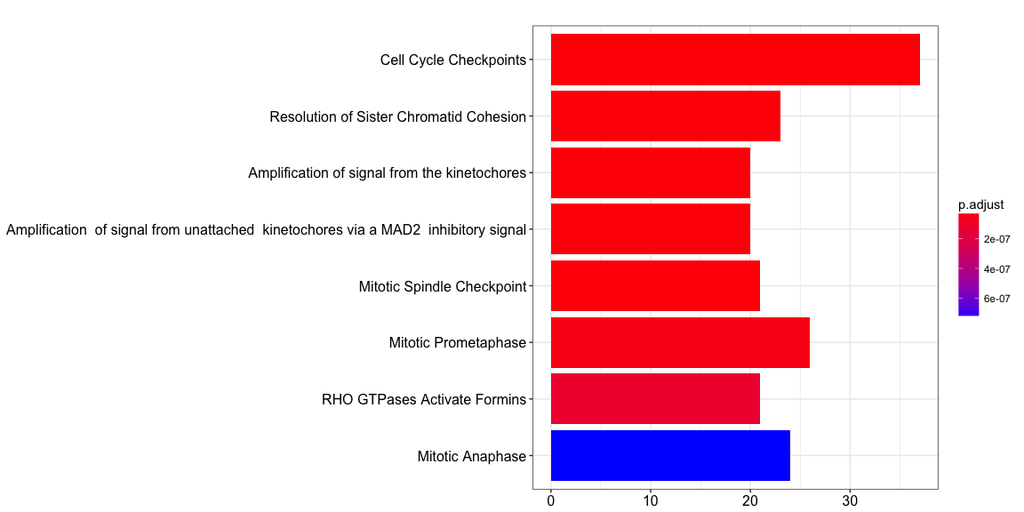

```r
barplot(x, showCategory=8)
```

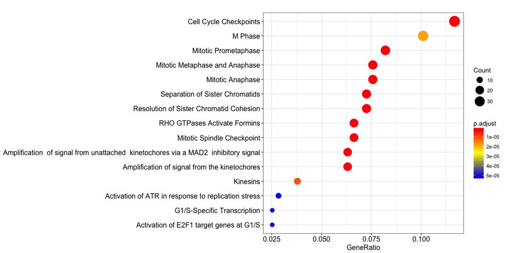

```r
dotplot(x, showCategory=15)
```

Enrichment map can be viusalized by *enrichMap*:

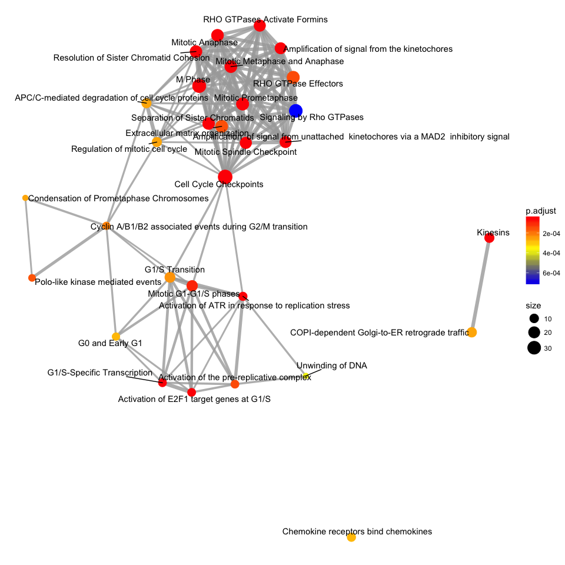

```r
emapplot(x)
```

In order to consider the potentially biological complexities in which a gene may belong to multiple annotation categories, we developed *cnetplot* function to extract the complex association between genes and diseases.

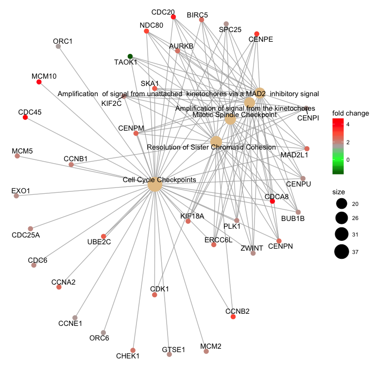

```r
cnetplot(x, categorySize="pvalue", foldChange=geneList)
```

## Comparing enriched reactome pathways among gene clusters with clusterProfiler

We have developed an `R` package clusterProfiler(Yu et al. 2012) for comparing biological themes among gene clusters. ReactomePA works fine with clusterProfiler and can compare biological themes at reactome pathway perspective.

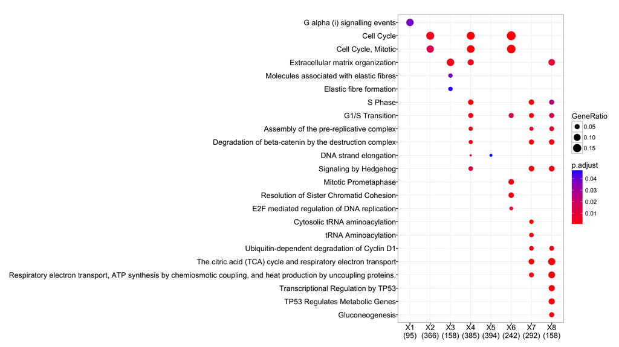

```r
require(clusterProfiler)
data(gcSample)
res <- compareCluster(gcSample, fun="enrichPathway")
dotplot(res)
```

# Gene Set Enrichment Analysis

A common approach in analyzing gene expression profiles was identifying differential expressed genes that are deemed interesting. The *enrichPathway* function we demonstrated previously were based on these differential expressed genes. This approach will find genes where the difference is large, but it will not detect a situation where the difference is small, but evidenced in coordinated way in a set of related genes. Gene Set Enrichment Analysis (GSEA)(Subramanian et al. 2005) directly addressed this limitation. All genes can be used in GSEA; GSEA aggregates the per gene statistics across genes within a gene set, therefore making it possible to detect situations where all genes in a predefined set change in a small but coordinated way. For algorithm details, please refer to the vignette of DOSE(Yu et al. 2015).

```r
y <- gsePathway(geneList, nPerm=10000,
                pvalueCutoff=0.2,
                pAdjustMethod="BH", verbose=FALSE)
res <- as.data.frame(y)
head(res)
```

```
##                          ID
## R-HSA-1474244 R-HSA-1474244
## R-HSA-216083   R-HSA-216083
## R-HSA-3000178 R-HSA-3000178
## R-HSA-2022090 R-HSA-2022090
## R-HSA-3000171 R-HSA-3000171
## R-HSA-1650814 R-HSA-1650814
##                                                                Description
## R-HSA-1474244                            Extracellular matrix organization
## R-HSA-216083                            Integrin cell surface interactions
## R-HSA-3000178                                            ECM proteoglycans
## R-HSA-2022090 Assembly of collagen fibrils and other multimeric structures
## R-HSA-3000171                       Non-integrin membrane-ECM interactions
## R-HSA-1650814                  Collagen biosynthesis and modifying enzymes
##               setSize enrichmentScore       NES       pvalue   p.adjust
## R-HSA-1474244     265      -0.4590060 -1.940644 0.0001336898 0.00275045
## R-HSA-216083       81      -0.5090432 -1.849902 0.0001526718 0.00275045
## R-HSA-3000178      72      -0.6266580 -2.232570 0.0001547509 0.00275045
## R-HSA-2022090      54      -0.5600621 -1.894856 0.0001586798 0.00275045
## R-HSA-3000171      56      -0.5863352 -1.995173 0.0001589825 0.00275045
## R-HSA-1650814      53      -0.5915513 -1.995083 0.0001590331 0.00275045
##                   qvalues rank                   leading_edge
## R-HSA-1474244 0.001986196 1943 tags=34%, list=16%, signal=29%
## R-HSA-216083  0.001986196 1890 tags=38%, list=15%, signal=33%
## R-HSA-3000178 0.001986196 1890 tags=46%, list=15%, signal=39%
## R-HSA-2022090 0.001986196 1897 tags=54%, list=15%, signal=46%
## R-HSA-3000171 0.001986196 2538 tags=45%, list=20%, signal=36%
## R-HSA-1650814 0.001986196 1890 tags=47%, list=15%, signal=40%
##                                                                                                                                                                                                                                                                                                          …
## R-HSA-1474244 8038/11132/4017/1288/4811/3910/3371/1291/3791/831/1301/4238/…
## R-HSA-216083                                                                                                                                                                                                                                                                                             …
## R-HSA-3000178                                                                                                                                                                                                                                                                                            …
## R-HSA-2022090                                                                                                                                                                                                                                                                                            …
## R-HSA-3000171                                                                                                                                                                                                                                                                                            …
## R-HSA-1650814                                                                                                                                                                                                                                                                                            …
```

## Visualize GSEA result

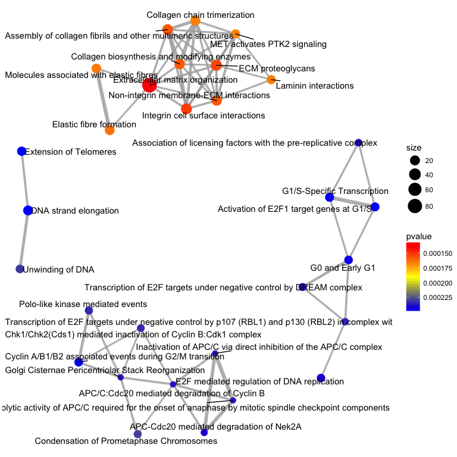

```r
emapplot(y, color="pvalue")
```

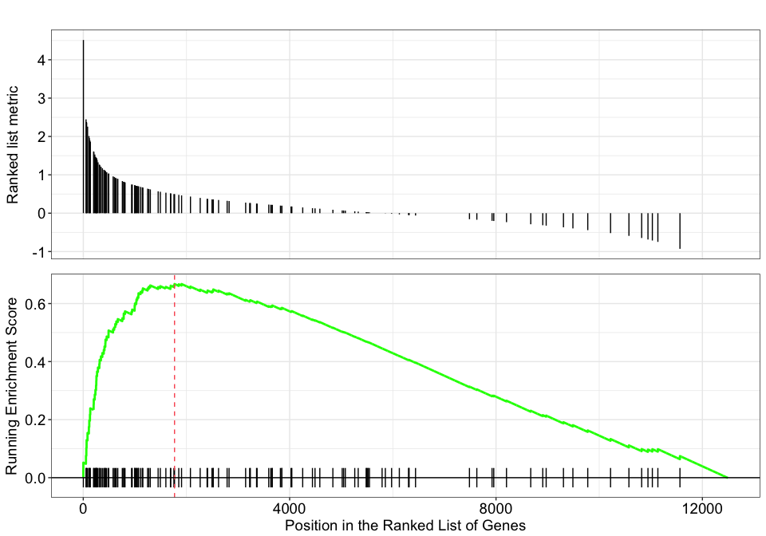

```r
gseaplot(y, geneSetID = "R-HSA-69242")
```

# Pathway Visualization

In ReactomePA, we also implemented *viewPathway* to visualized the pathway.

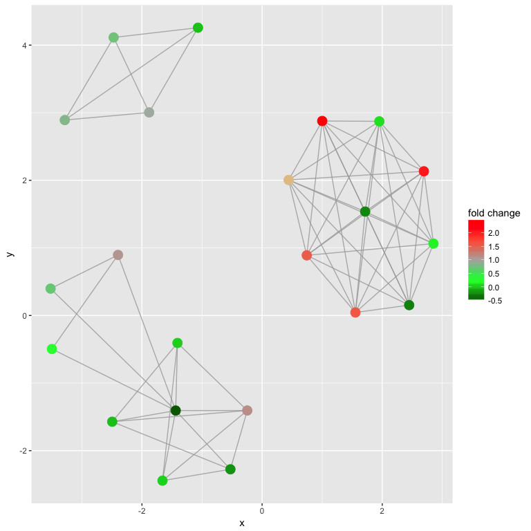

```r
viewPathway("E2F mediated regulation of DNA replication", readable=TRUE, foldChange=geneList)
```

More documents can be found on the project website, https://guangchuangyu.github.io/ReactomePA.

# References

Boyle, Elizabeth I, Shuai Weng, Jeremy Gollub, Heng Jin, David Botstein, J Michael Cherry, and Gavin Sherlock. 2004. “GO::TermFinder–open Source Software for Accessing Gene Ontology Information and Finding Significantly Enriched Gene Ontology Terms Associated with a List of Genes.” *Bioinformatics (Oxford, England)* 20 (18): 3710–5. doi:10.1093/bioinformatics/bth456.

Subramanian, Aravind, Pablo Tamayo, Vamsi K. Mootha, Sayan Mukherjee, Benjamin L. Ebert, Michael A. Gillette, Amanda Paulovich, et al. 2005. “Gene Set Enrichment Analysis: A Knowledge-Based Approach for Interpreting Genome-Wide Expression Profiles.” *Proceedings of the National Academy of Sciences of the United States of America* 102 (43): 15545–50. doi:10.1073/pnas.0506580102.

Yu, Guangchuang, and Qing-Yu He. 2016. “ReactomePA: An R/Bioconductor Package for Reactome Pathway Analysis and Visualization.” *Molecular BioSystems* 12 (2): 477–79. doi:10.1039/C5MB00663E.

Yu, Guangchuang, Li-Gen Wang, and Qing-Yu He. 2015. “ChIPseeker: An R/Bioconductor Package for Chip Peak Annotation, Comparison and Visualization.” *Bioinformatics* 31 (14): 2382–3. doi:10.1093/bioinformatics/btv145.

Yu, Guangchuang, Li-Gen Wang, Yanyan Han, and Qing-Yu He. 2012. “clusterProfiler: an R Package for Comparing Biological Themes Among Gene Clusters.” *OMICS: A Journal of Integrative Biology* 16 (5): 284–87. doi:10.1089/omi.2011.0118.

Yu, Guangchuang, Li-Gen Wang, Guang-Rong Yan, and Qing-Yu He. 2015. “DOSE: An R/Bioconductor Package for Disease Ontology Semantic and Enrichment Analysis.” *Bioinformatics* 31 (4): 608–9. doi:10.1093/bioinformatics/btu684.